```python
%matplotlib inline
import matplotlib
import matplotlib.pyplot as plt
matplotlib.rc('font', size=22)
matplotlib.rc('figure', figsize=(18, 10))

import numpy as np
import scipy as sp
import pandas as pd
import h5py
from scipy import stats
from scipy.signal import argrelmax
from scipy.optimize import curve_fit
hf = h5py.File('gammaray_lab4.h5', 'r')
hf.keys()
```

```
<KeysViewHDF5 ['data']>
```

# problem 1

```python
with h5py.File('gammaray_lab4.h5', 'r') as hf:
    data = np.array(hf.get('data'))
```

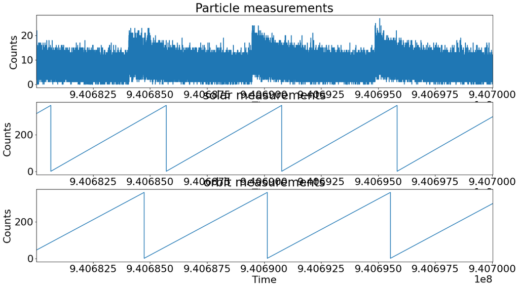

```python
N=200000
plt.subplot(3,1,1)
plt.plot(data[0][0:N], data[3][0:N]);
plt.xlim(data[0][0], data[0][N])
plt.title("Particle measurements")
plt.xlabel('Time')
plt.ylabel('Counts')

plt.subplot(3,1,2)
plt.plot(data[0][0:N], data[1][0:N]);
plt.xlim(data[0][0], data[0][N])
plt.title("solar measurements")
plt.xlabel('Time')
plt.ylabel('Counts')

plt.subplot(3,1,3)
plt.plot(data[0][0:N], data[2][0:N]);
plt.xlim(data[0][0], data[0][N])
plt.title("orbit measurements")
plt.xlabel('Time')
plt.ylabel('Counts')
```

We can tell that these datas are periodic, so it will might meet some other source of radiation in the orbit.

2

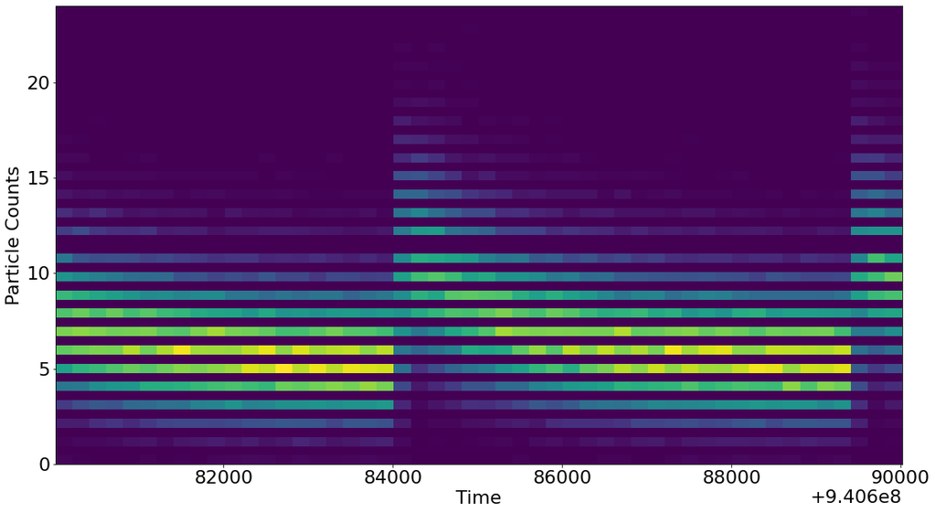

```python
plt.hist2d(data[0,:100000],data[3,:100000],50)
plt.xlabel("Time")
plt.ylabel("Particle Counts")
plt.show()
```

3

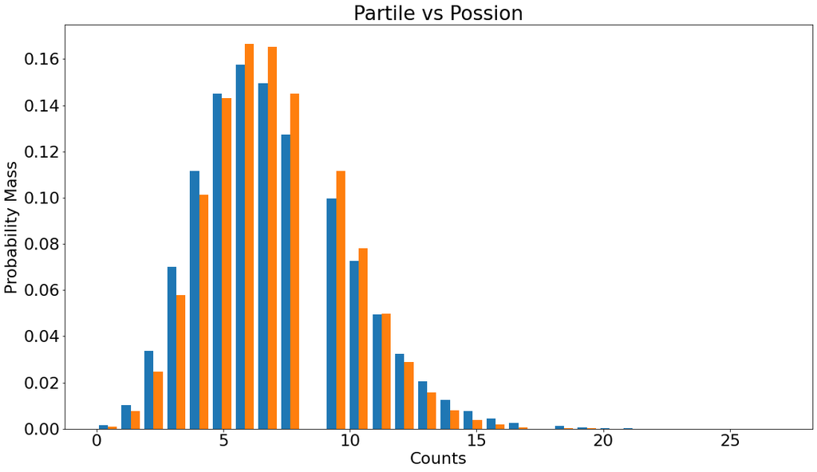

```python
dist = stats.poisson(7)
vals = dist.rvs(N)
plt.hist([data[3][0:N], vals], bins=30, density=True)
plt.title('Partile vs Possion')
plt.xlabel('Counts')
plt.ylabel('Probability Mass')
```

As we can see the raw data is not follwing the possion distribution very well,poisson distribution slightly overpresidct but because it is raw data it is ok to have that, over all the graph shows a good tread.

4.

```python
sig=stats.norm.sf(5)
five_counts=int(stats.poisson.isf(sig,5))
six_counts = int(stats.poisson.isf(sig,7))
print('For 5 counts, a 5 sigma threshold value is ' + str(five_counts))
print('For 6 counts, a 5 sigma threshold value is ' + str(six_counts))
```

```
For 5 counts, a 5 sigma threshold value is 20
For 6 counts, a 5 sigma threshold value is 24
```

# problem 2

2.

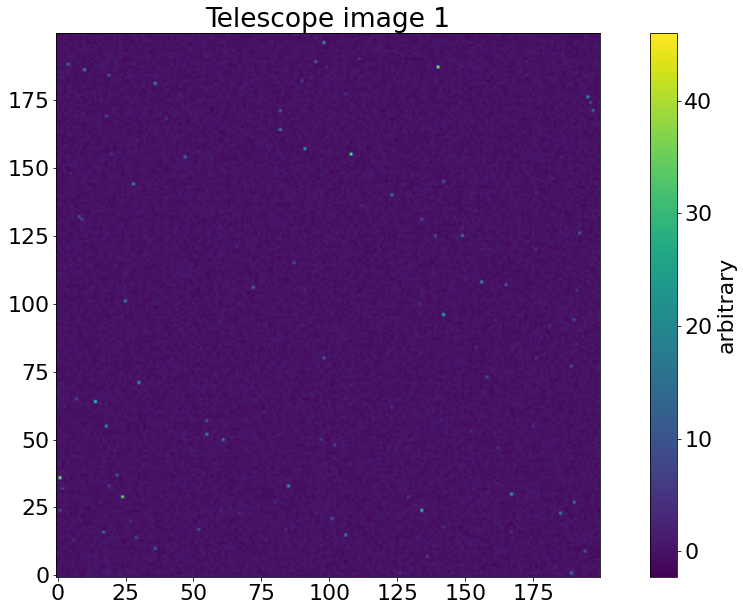

```python
with h5py.File('images.h5', 'r') as hf:
    img_data = np.array(hf.get('imagestack'))

plt.title('Telescope image 1')
plt.imshow(img_data[:, :, 0], origin='lower')
cbar = plt.colorbar()
cbar.set_label('arbitrary')
```

```
Mean -0.003167586768696385, Std dev 0.5616091705025514
```

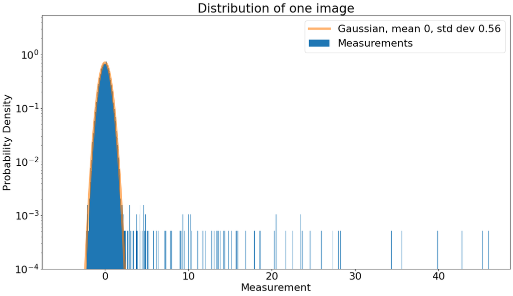

```python
plt.title('Distribution of one image')
plt.xlabel('Measurement')
plt.ylabel('Probability Density')
image1_measurements = img_data[:, :, 0].flatten()
plt.hist(image1_measurements, bins=1000, density=True)
relevant_data_1 = image1_measurements[image1_measurements < 2]
mean = np.mean(relevant_data_1)
std_dev = np.std(relevant_data_1)
print(f"Mean {mean}, Std dev {std_dev}")
x = np.linspace(-5, 5, 1000)
y = stats.norm(mean, std_dev).pdf(x)
plt.plot(x, y, linewidth=5, alpha=0.6)
plt.yscale('log')
plt.ylim(1e-4, None)
plt.legend([f"Gaussian, mean 0, std dev {std_dev.round(2)}", 'Measurements']);
```

Only a few ratio of the signal contamination. For the most part, the back ground appears to be Gaussian distributed with a mean very close to 0 and a width of about 0.56 units.We can tell it is not time-dependent due to all datas are recorded at same time. While it is hard to determine if the distribution of all images are time-dependent, because we do not know when did each image was token.

3

```
2.8048782657273112
```

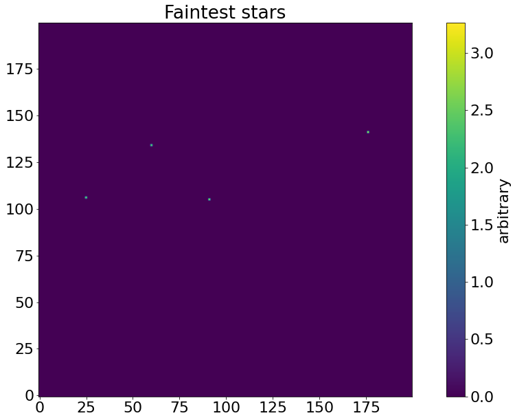

```python
average_img = np.mean(img_data, axis=2)
threshold = stats.norm(mean, std_dev).ppf(stats.norm.cdf(5))
print(threshold)
delta = 0.5
detections = (average_img > threshold) & (average_img < threshold + delta)
plt.title('Faintest stars')
plt.imshow(average_img * detections, origin='lower')
cbar = plt.colorbar()
cbar.set_label('arbitrary')
```

we can see 4 stars from 10-image average

4.

My partner concerns more about the discrepancy between these two images, the standard deviation of the sum or difference would be even larger , equal to $\sigma_k = \sqrt{\sigma_i^2 + \sigma_j^2}$. The $5\sigma$ threshold value will be larger, if the value of $\sigma$ is larger.